# Team Checkpoint 1

Forest Cover Team B

Annie Condon, Matt Hayden, Matt Robertson, Yvette Gonzalez

# 1 Introduction

The U.S. Forest Service relies on an accurate understanding of its forests’ composition in order to best protect and manage the forest land. Conducting accurate inventory of forest composition by direct observation or remotely sensed data is often too expensive and time consuming to do at large-scale. Predictive analytics, however, can be employed to use the results of a small-scale survey to create a model that can be applied across a large region, using descriptive features extracted from maps of the area.

In this paper, our objective is to predict the forest cover type given a set of cartographic features and a variety of mulitclass classification models. Our models will be evaluated using predictive accuracy.

# 2 The Modeling Problem

Our modeling problem is to predict the forest cover type as a multiclass classification problem based on the associated features. A multiclass classification problem classifies instances into one of the more than two classes. Our forest cover type is defined as one of seven, mutually exclusive, forest cover type classes, shown in table 1 below.

Cover Type Classes

| Cover Type | Number of Observations |
| --- | --- |
| Spruce/Fir | 211840 |
| Lodgepole Pine | 283301 |
| Ponderosa Pine | 35754 |
| Cottonwood/Willow | 2747 |
| Aspen | 9493 |
| Douglas/Fir | 17367 |
| Krummholz | 20510 |

Several algorithms have been developed to solve multiclass classification problems. The possible algorithms we will consider for our problem are: neural networks, k-nearest neighbors, random forest and support vector machines.

We will evaluate our models using classification accuracy.

# 3 The Data

The actual forest cover type for a given 30 x 30 meter cell was determined from US Forest Service (USFS) Region 2 Resource Information System data. Independent variables were then derived from data obtained from the US Geological Survey and USFS. The data is from four wilderness areas in the Roosevelt National Forest, located in north central Colorado. These areas represent forests with minimal human-caused disturbances, so that existing forest cover types are more a result of ecological processes rather than forest management practices.

Our data set consists of 581,012 observations of the 30 x 30 meter cells of forest and 54 features associated with each cell. The features are derived from 12 attributes, with area and soil type binarized so that there are 4 binary area designators and 40 binary soil type designators. The feature descriptions are listed in the table below:

Features

| Feature | Descriptions |
| --- | --- |
| Elevation | Elevation in meters |
| Aspect | Aspect in degrees aziumuth |
| Slope | Slope in degrees |
| HDist.Hydrology | Horizontal distance to nearest surface water feature in meters |
| VDist.Hydrology | Vertical distance to nearest surface water feature in meters |
| HDist.Roadway | Horizontal distance to nearest roadway in meters |
| Hillshade.9am | Hillshade index at 9am, summer solstice |
| Hillshade.12pm | Hillshade index at noon, summer soltice |
| Hillshade.3pm | Hillshade index at 3pm, summer solstice |
| HHDist.FirePoint | Horizontal Distance to nearest wildfire ignition points |
| Area | Wilderness area designation - 4 binary areas |
| SoilType | Soil Type designation - 40 binary values |

## 3.1 Response Variable

Figure one shows the frequency of each class of cover type in our data set. 85 percent of the observations fall into classes 1 and 2, Spruce/Fir and Lodgepole Pine. Class 4, Cottonwood/Willow has the least amount of observations at 2,747.

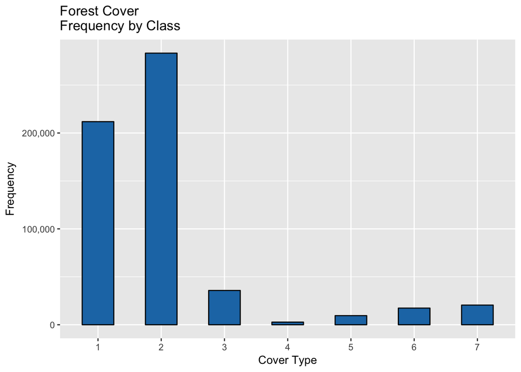

Frequency of each Cover Type Class

## 3.2 Continuous Variables

Table 3 includes some standard statistical measures of central tendency and variation for our continuous variables.

Summary Statistics for Continuous Data

|  | mean | sd | median | min | max | type |
| --- | --- | --- | --- | --- | --- | --- |
| Elevation | 2959.3653 | 279.9847 | 2996 | 1859 | 3858 | Continuous |
| Aspect | 155.6568 | 111.9137 | 127 | 0 | 360 | Continuous |
| Slope | 14.1037 | 7.4882 | 13 | 0 | 66 | Continuous |
| HDist.Hydrology | 269.4282 | 212.5494 | 218 | 0 | 1397 | Continuous |
| VDist.Hydrology | 46.4189 | 58.2952 | 30 | -173 | 601 | Continuous |
| HDist.Roadway | 2350.1466 | 1559.2549 | 1997 | 0 | 7117 | Continuous |
| Hillshade.9am | 212.146 | 26.7699 | 218 | 0 | 254 | Continuous |
| Hillshade.12pm | 223.3187 | 19.7687 | 226 | 0 | 254 | Continuous |
| Hillshade.3pm | 142.5283 | 38.2745 | 143 | 0 | 254 | Continuous |
| HDist.FirePoint | 1980.2912 | 1324.1952 | 1710 | 0 | 7173 | Continuous |

## 3.3 Binary Variables

# 4 Exploratory Data Analysis

Our next step is to explore the relationships in our data. We will begin by looking at boxplots of our scaled continuous variables in order to understand their relative distribution. We note that Hillshade.12pm and VDist.Hydrology have more pronounced skews than the other variables. We will need to investigate transformations if we use modeling techniques that can be negatively effected by outliers.

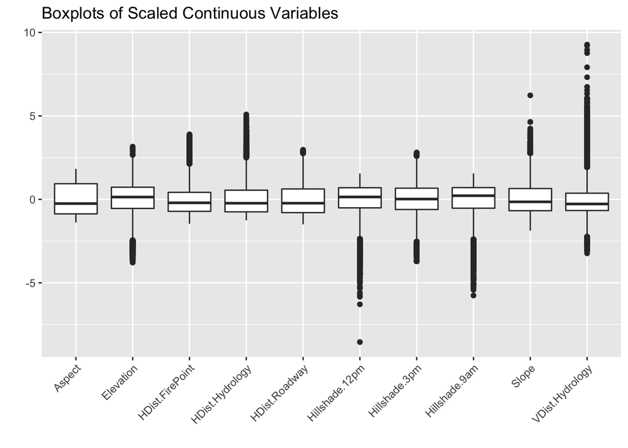

Boxplots of Scaled Continuous Variables

Our data exploration is informed by our statistical problem, which is one of multiclass classification. We will therefore be interested in exploring our predictors by each of our classes. The density plots below superimpose the density estimates for each variable by class, 1-7. We note that our variable Aspect shows multimodel distributions, indicating that it may have more than one grouping included. We will also note that several of our variables show distinct distributions by class, indicating that they would serve as a good predictor.

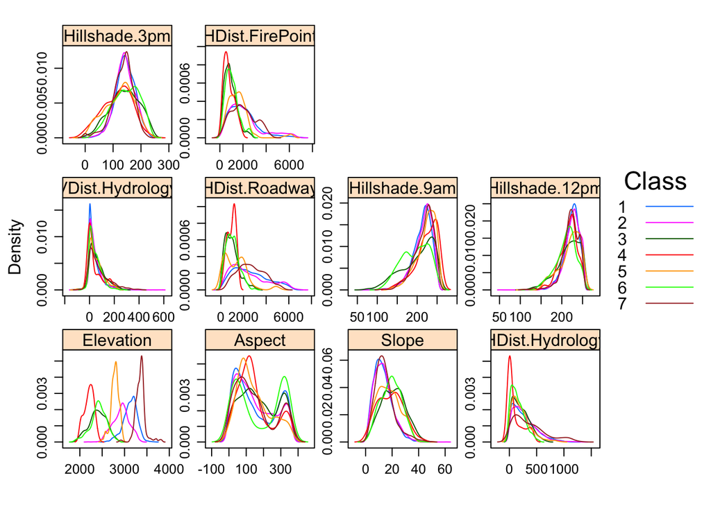

Density Plots by Class

Figure 4 shows density plots by each of the four wilderness areas.

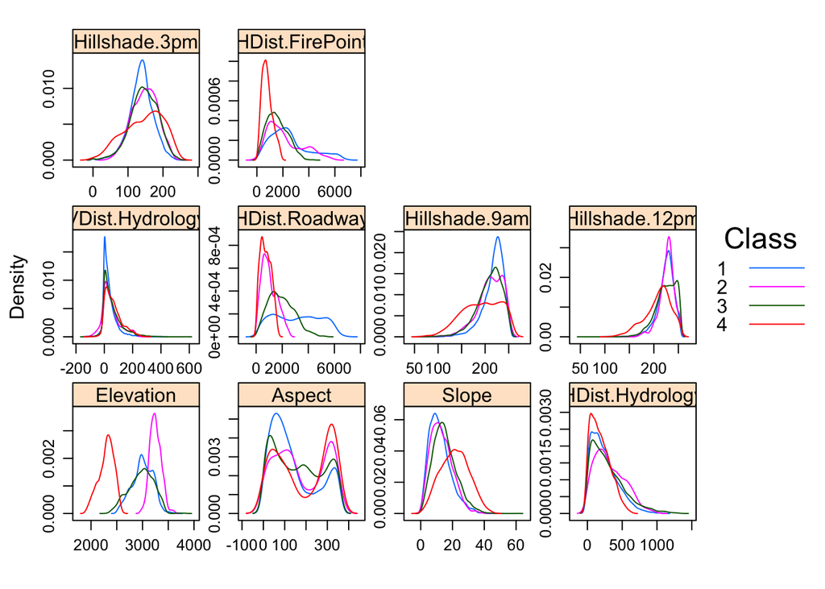

Density Plots by Area

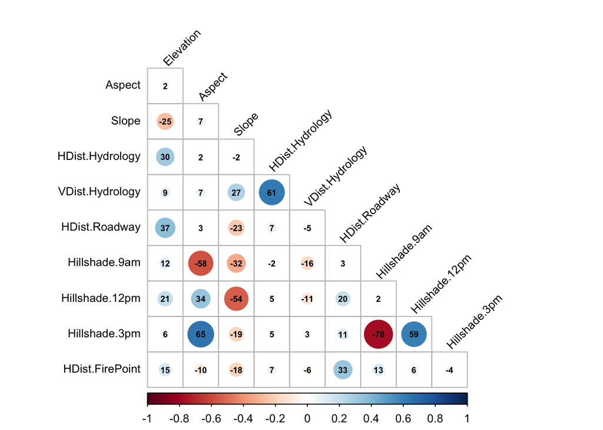

Correlation Matrix

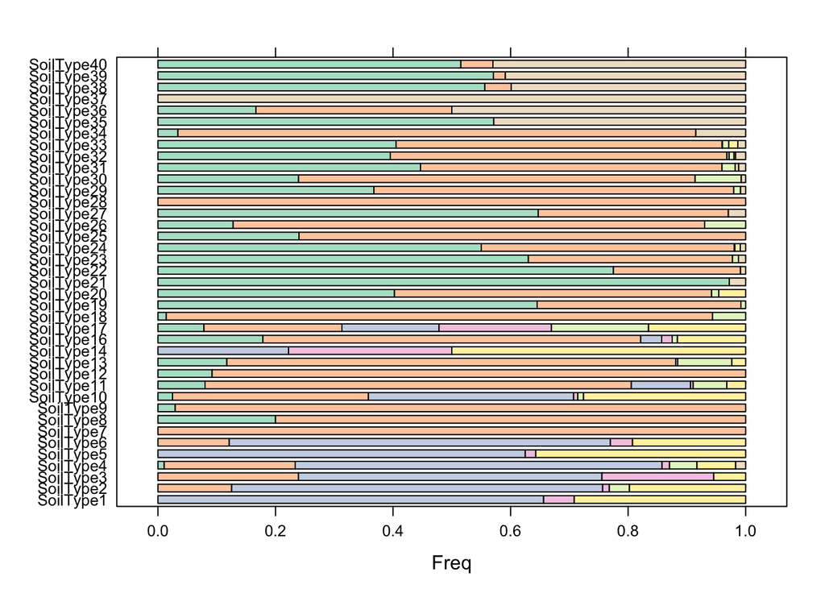

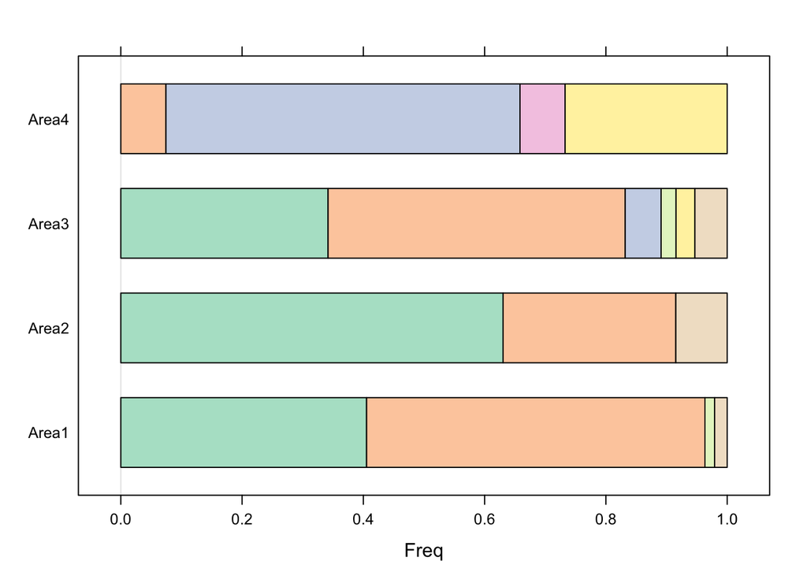